# Spore Heat resistance test

*Chian Jung Chen, Daniel Schwartz and Jay Lennon*

In the host-phage interaction, when infecting cells undergoing sporulation, phage genomes can get entrapped in dormant cells (i.e., viral spores) and start infection upon spore germination. Past research found that some homologs of bacteria sporulation genes were carried by phages. However, the reason why phages carry these genes is still unknown. One of these homologs is the *ssp* gene, which encodes for small acid-soluble spore proteins (SASP). SASPs are double-stranded DNA-binding proteins that change the conformation of DNA, protecting the spore from heat, UV radiation, and enzymatic degradation.

In Bacillus subtilis there are 16 *ssp* paralogs (*sspA*…*sspP*), however spore protection is mediated almost entirely by the 2 major SASPs encoded by *sspA* and *sspB*. The *ssp* homologs found in phages SPO1 and Goe2 are most similar to the major *ssp* genes.

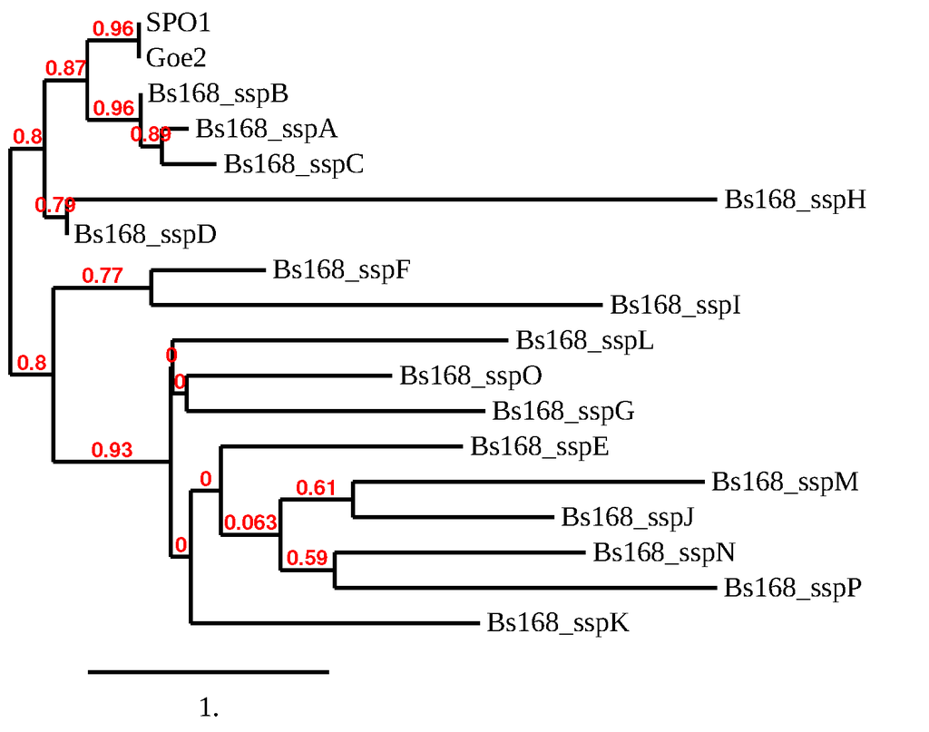

phylogeny

**AA alignment phylogeny by phylogeny.fr**

A double knockout B. subtilis strain $\Delta sspAB$ sporulates like the Wild-type (WT), but the spores made have reduced heat resistance (Mason and Setlow 1986 JBac 167:174).

Based on the host function of the homolog and phage entrapment properties, we hypothesized that phage *ssp* homologs promote spore heat resistance and will help restore heat resistance of spores made by $\Delta sspAB$.

## Preliminary test of spore heat-resistance

We obtained the $\Delta sspAB$, $\Delta sspC$ and $\Delta sspD$ strains from the BGSC and tested the heat resistance of their spores alongside the B. subtilis 168 WT.For this strains were allowed to sporulate for 2 days in DSM before spores were purified. Spores were then subjected to heat treatment at $90 ^\circ C$ and plated to estimate viable spores from CFU counts. Spore survival data below is presented ad fraction survivors relative to non treated sample (t=0).

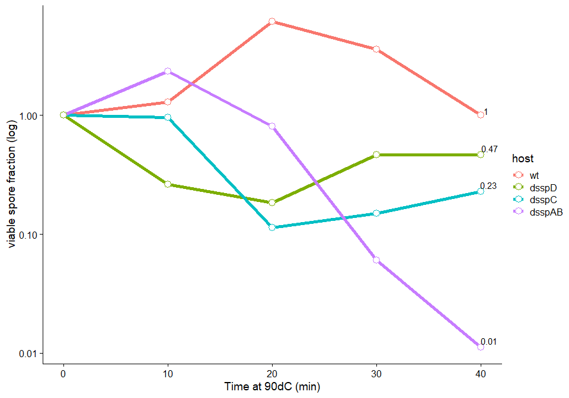

```r
d%>%
  mutate(host=fct_rev(host))%>%
  filter(!filter)%>%
  filter(date==20200118)%>%
  #there are 4 rows with data marked as "TMC" (=Too Many to Count)
  # these are coerced into NA
  mutate(counts=as.numeric(counts ))%>%
  mutate(no.ml = counts/(dilution*ml.plated))%>%
  # group_by(host)%>%
  mutate(perc = no.ml/no.ml[heat.min==0])%>%
  ggplot(aes(x=heat.min, y=perc))+
    # geom_smooth(aes(color=host),method = "lm", se=F, size=2)+
    geom_line(aes(color=host), size=2)+
    geom_point(aes(color=host),size=4, shape=21, fill="white")+
    geom_text_repel(data=.%>%filter(heat.min>35),aes(label=perc%>%round(digits = 2)))+
  scale_y_log10()+
  theme_cowplot()+
  ylab("viable spore fraction (log)")+
  xlab("Time at 90dC (min)")
```

The largest reduction in heat resistance was seen in $\Delta sspAB$, and it is with this strain that we proceeded to the next step.

## Preliminary spore resistance test with phage

To test if phages carrying *ssp* homologs may restore the heat resistance when infecting a host with reduced resistance, $\Delta sspAB$ were induced to sporulate, as described above, but were infected with phage at the onset of sporulation. After 2 days spores were purified and subjected to heat resistance test. Since infected cultures contain both regular spores and viral-spores (due to entrapment) spore viability in during heat treatment was measured by plating for both colony and plaque forming units and these results are presented separately. As controls spores from non-infected WT and $\Delta sspAB$ were also tested by CFU plating.

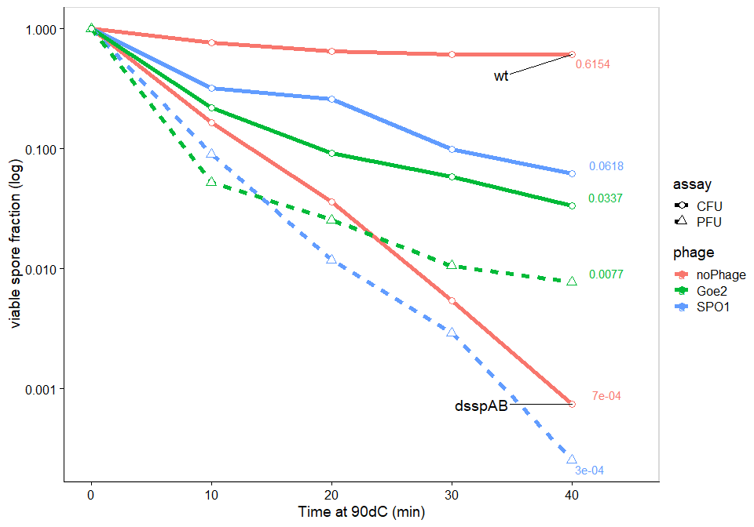

```r
d%>%
  mutate(phage=fct_relevel(phage,c("noPhage","Goe2", "SPO1")))%>%
  mutate(host=fct_rev(host))%>%
  filter(host=="wt"|host=="dsspAB")%>%
  filter(date!=20200118)%>%
  filter(!filter)%>%
  filter(group=="preliminary")%>%
  #there are 4 rows with data marked as "TMC" (=Too Many to Count)
  # these are coerced into NA
  mutate(counts=as.numeric(counts ))%>%
  mutate(no.ml = counts/(dilution*ml.plated))%>%
  group_by(host,phage,assay, date)%>%
  mutate(perc = no.ml/no.ml[heat.min==0])%>%
  ggplot(aes(x=heat.min, y=perc))+
    geom_line(aes(group=interaction(date,assay, host),color=phage, linetype=assay), size=2)+
    geom_point(aes(group=interaction(date,assay, host),color=phage, shape=assay), size=3, fill="white")+
  scale_y_log10()+
  scale_shape_manual(values = c(21,24))+
      geom_text_repel(data=.%>%filter(heat.min>35),aes(x=heat.min+2,label=perc%>%round(digits = 4),color=phage), xlim = c(40, NA) )+
    geom_text_repel(data=.%>%filter(heat.min>35 & phage=="noPhage"),aes(label=host),size=5,xlim = c(NA,35), ylim = c(NA,log10(0.5)))+
  theme_cowplot()+
  panel_border()+
  ylab("viable spore fraction (log)")+
  xlab("Time at 90dC (min)")+
  xlim(0,45)
```

## Replicated spore resistance assay

In this experiment both the WT and $\Delta sspAB$ strains were induced to sporulate in DSM. At the onset of sporulation each of the cultures were infected (MOI=3) with either phage SPO1, phage Goe2 , or with no phage as a control. after 2 days spores were purified and subjected to heat resistance test where both CFU and PFU were measured, following regular and viral spores, respectively.  
The experiment had replication of n=3. where the sporulation and infection assays were all done together. Purified spores were then stored in the fridge. The heat resistance tests were then conducted in 3 groups, on separate days, each consisting of all treatments at n=1. Samples were plated before heat treatment (t=0) and after 15,30 and 45 min of heat treatment.  
To make sure we were looking at heat response of viral spores, and not free viruses, samples of the purified spores were filtered and plaque assayed to measure the levels of free phages (spores exclude by filter while free phages pass through).

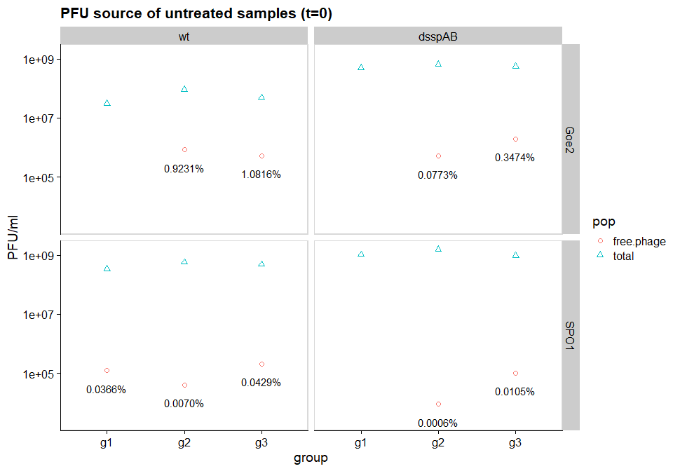

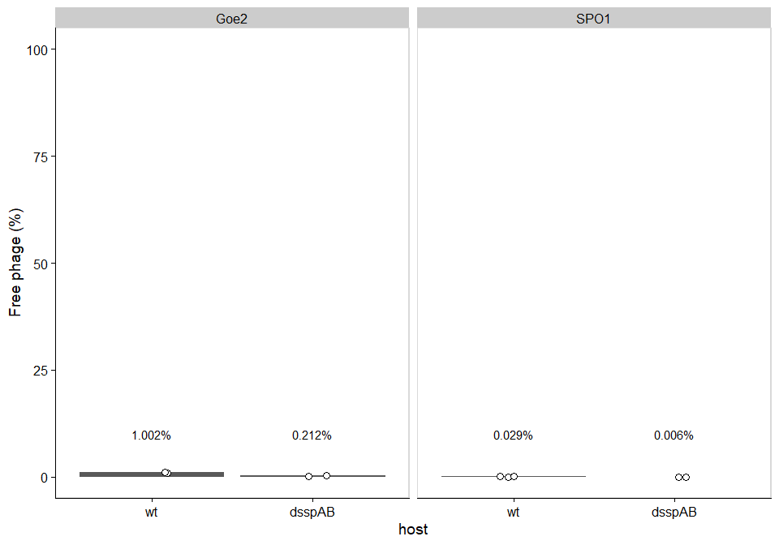

In all cases measured the free phages were only a small fraction of the total PFU, being 1.1% or lower. Therefore, we can attribute any PFU decline observed in heat treatment to the change in spore viability. For 3 samples (all in group.1) the filtered sample plating was not sufficiently diluted for enumeration.

Next we present the change in titer during heat treatment, normalized to t=0.

Looking first at non-infected controls:

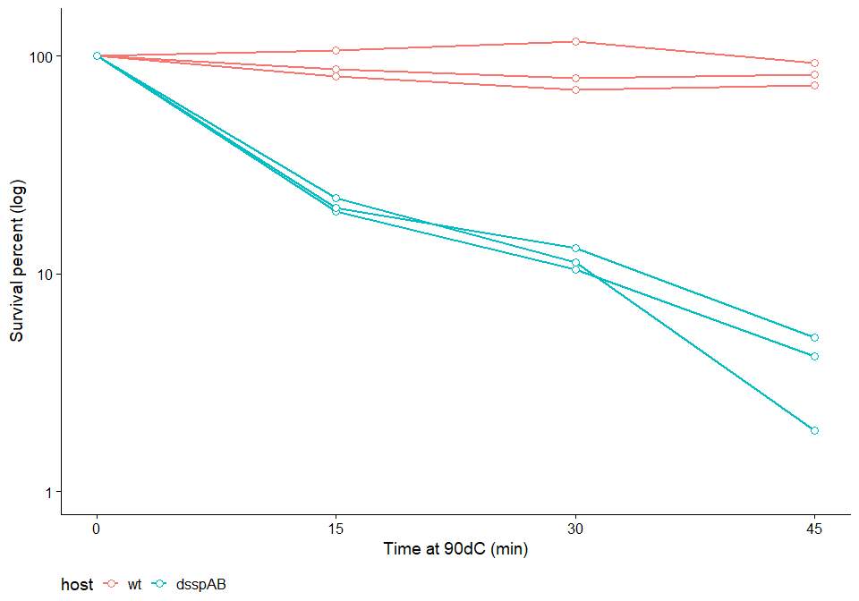

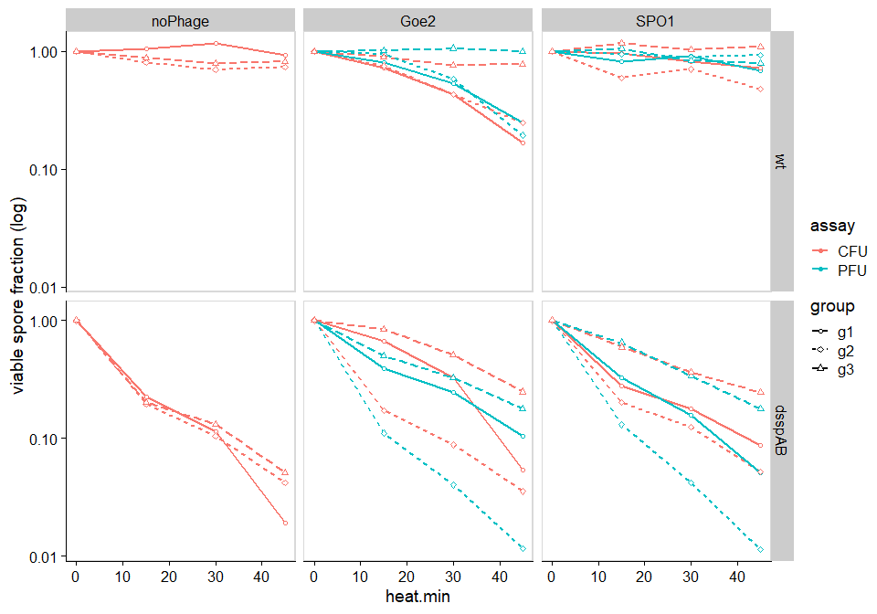

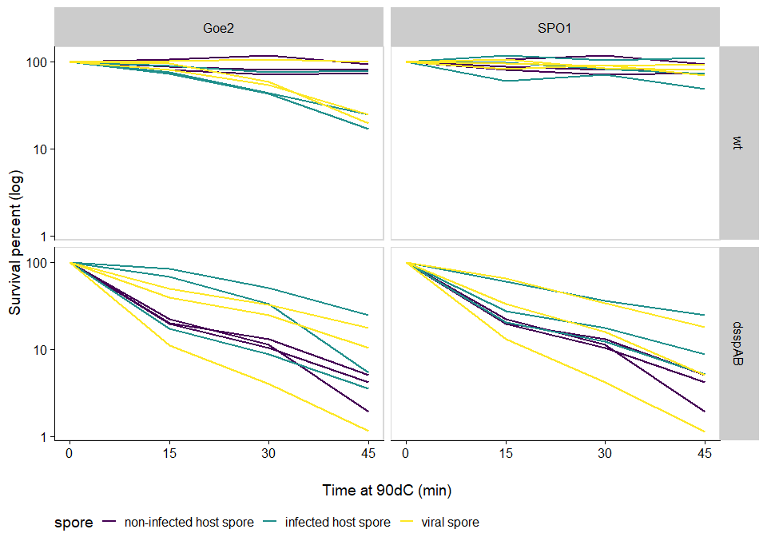

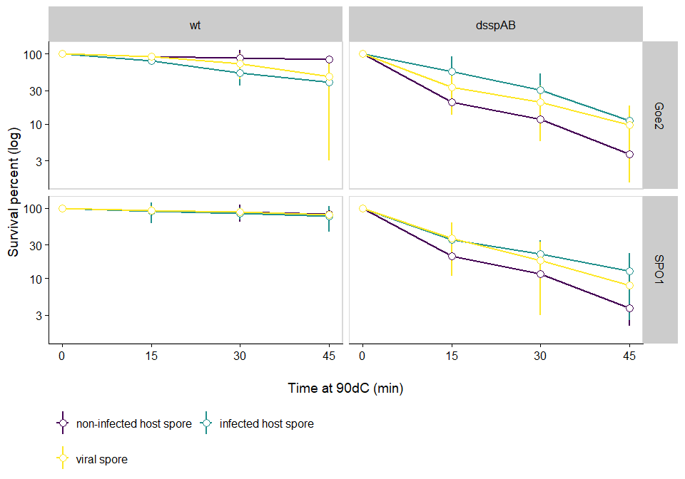

# Plot lines of paired samples

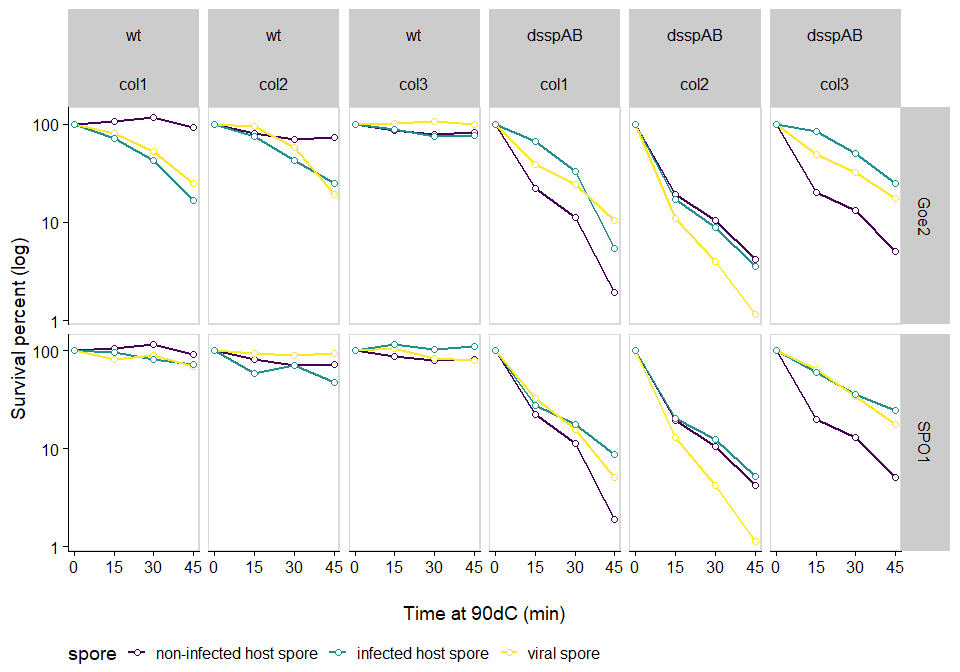

```r
p.decay.colony <-
d.rep.plot%>%
  mutate(spore=as_factor(spore))%>%
  mutate(spore=fct_relevel(spore,c("non-infected host spore","infected host spore","viral spore")))%>%
  mutate(colony=str_replace(group,"g","col"))%>%
    ggplot(aes(x=heat.min, y=perc, color=spore))+
    geom_line(aes(group=interaction(host,phage,assay,group,spore)),size=1)+
    geom_point(size=2,shape=21, fill="white")+
  scale_y_log10()+
  facet_grid(phage ~ host + colony)+
  theme_cowplot()+
  panel_border()+
  xlab("Time at 90dC (min)")+
  ylab("Survival percent (log)")+
  # scale_color_manual(values = c("black", "red", "violet"))+
  scale_color_viridis_d()+
  scale_x_continuous(breaks = c(0,15,30,45))+
  theme(legend.position = "bottom")

p.decay.colony+
  ggsave2(here("figures", "paired_heatTreat_ALL.png"),width = 6,height = 6)
```

## Comparing slopes

To be able to compare the heat-resistance of different samples and treatments we next estimate the slope of each curve by fitting a linear model. The estimated parameters of the models are given in the following tables, where each line is a single parameter (see column `term`; `heat.min` is the slope).

| host | phage | assay | group | term | estimate | std.error | statistic | p.value |
| --- | --- | --- | --- | --- | --- | --- | --- | --- |
| wt | noPhage | CFU | g1 | (Intercept) | 2.0234120210 | 0.0423276884 | 47.8035087 | 4.373161e-04 |
| wt | noPhage | CFU | g1 | heat.min | -0.0004014206 | 0.0015083401 | -0.2661340 | 8.150610e-01 |
| wt | noPhage | CFU | g2 | (Intercept) | 1.9741226520 | 0.0341150238 | 57.8666650 | 2.985029e-04 |
| wt | noPhage | CFU | g2 | heat.min | -0.0030983637 | 0.0012156831 | -2.5486606 | 1.255939e-01 |
| wt | noPhage | CFU | g3 | (Intercept) | 1.9831685958 | 0.0227605474 | 87.1318498 | 1.316923e-04 |
| wt | noPhage | CFU | g3 | heat.min | -0.0019591176 | 0.0008110683 | -2.4154780 | 1.370284e-01 |
| wt | Goe2 | CFU | g1 | (Intercept) | 2.0634875182 | 0.0814760295 | 25.3263141 | 1.555399e-03 |
| wt | Goe2 | CFU | g1 | heat.min | -0.0170718755 | 0.0029033846 | -5.8799910 | 2.772597e-02 |
| wt | Goe2 | CFU | g2 | (Intercept) | 2.0354701484 | 0.0383121676 | 53.1285562 | 3.540897e-04 |
| wt | Goe2 | CFU | g2 | heat.min | -0.0137432628 | 0.0013652477 | -10.0664979 | 9.724605e-03 |

[output cut: 50 more lines]

# plot estimated slopes

Next we plot the predicted linear models to see if they are in agreement with measured points.

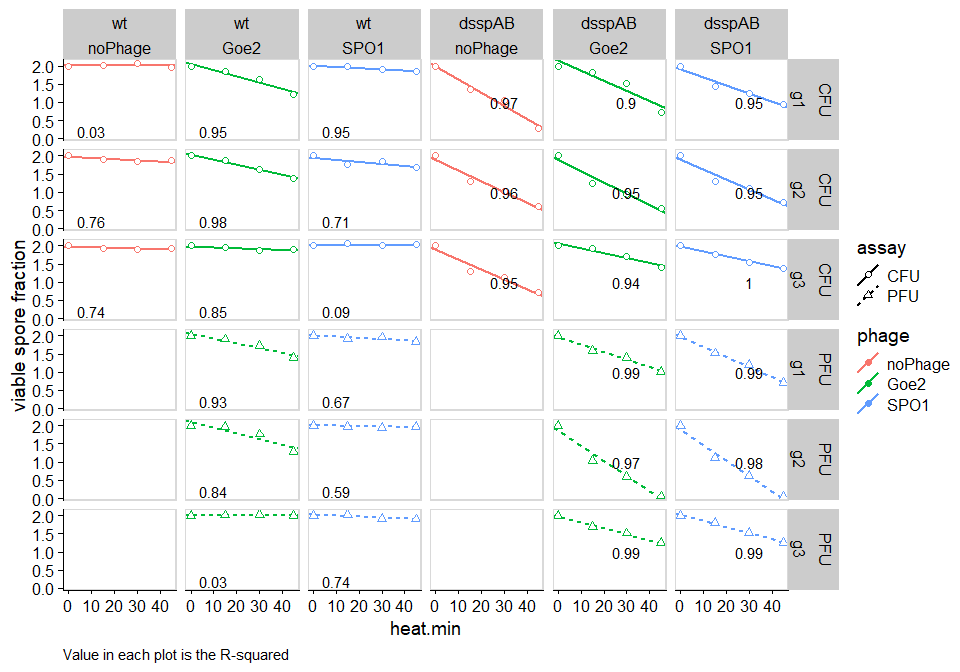

Overall the linear model plots seem to capture the trend of the data. I am not sure how much to make of it but the p-values given for the parameters are not very low. This can be seen in the plot below for the slope. I still need to find what this all means about the ability to use slope data.

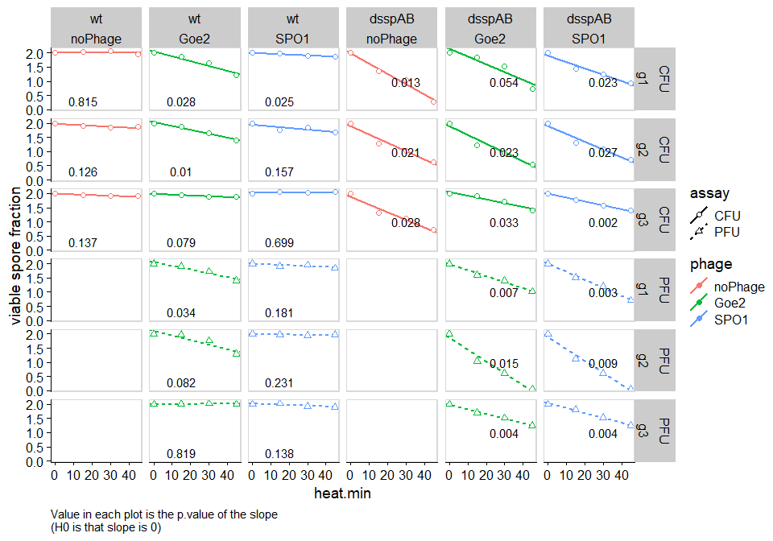

# Plot lines of paired samples

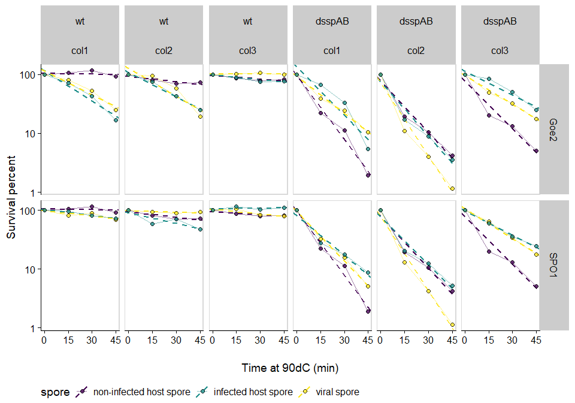

```r
# arrange slope estimate data for plotting
#replicate nophage data for bith phages
d.lm.goe2 <- d.lm.estimates%>%
  filter(phage!="SPO1")%>%
      mutate(spore=case_when(assay=="PFU" ~ "viral spore",
                           phage=="noPhage" ~ "non-infected host spore",
                           TRUE ~ "infected host spore"))%>%
  mutate(spore=as_factor(spore))%>%
  mutate(spore=fct_relevel(spore,c("non-infected host spore","infected host spore","viral spore")))%>%
    mutate(colony=str_replace(group,"g","col"))%>%
  mutate(phage="Goe2")

d.lm.spo1 <- d.lm.estimates%>%
  filter(phage!="Goe2")%>%
      mutate(spore=case_when(assay=="PFU" ~ "viral spore",
                           phage=="noPhage" ~ "non-infected host spore",
                           TRUE ~ "infected host spore"))%>%
  mutate(spore=as_factor(spore))%>%
  mutate(spore=fct_relevel(spore,c("non-infected host spore","infected host spore","viral spore")))%>%
    mutate(colony=str_replace(group,"g","col"))%>%
  mutate(phage="SPO1")

d.lm.plot <- (rbind(d.lm.goe2,d.lm.spo1))


p.slope.colony <-
d.rep.plot%>%
  mutate(spore=as_factor(spore))%>%
  mutate(spore=fct_relevel(spore,c("non-infected host spore","infected host spore","viral spore")))%>%
  mutate(colony=str_replace(group,"g","col"))%>%
    ggplot(aes(x=heat.min, y=perc, color=spore))+
    geom_line(aes(group=interaction(host,phage,assay,group,spore)),size=.3,alpha=.5)+
   geom_abline(data=d.lm.plot,
                aes(slope=slope, intercept=intercept, color=spore),size=1, linetype=2)+
    geom_point(aes(fill=spore),size=2,shape=21, alpha=.8, color="black")+
  facet_grid(phage ~ host + colony)+
  theme_cowplot()+
  panel_border()+
  xlab("Time at 90dC (min)")+
  ylab("Survival percent")+
  # scale_color_manual(values = c("black", "red", "violet"))+
  scale_color_viridis_d()+
  scale_fill_viridis_d()+
  scale_x_continuous(breaks = c(0,15,30,45))+
  theme(legend.position = "bottom")+
  scale_y_log10()
#
p.slope.colony+
  ggsave2(here("figures", "paired_slopes.png"),width = 6,height = 6)
```

If we do take the slopes as meaningful we can now ask if the presence of phage has an effect on the response of spore titer to heat treatment. First a look at the data.

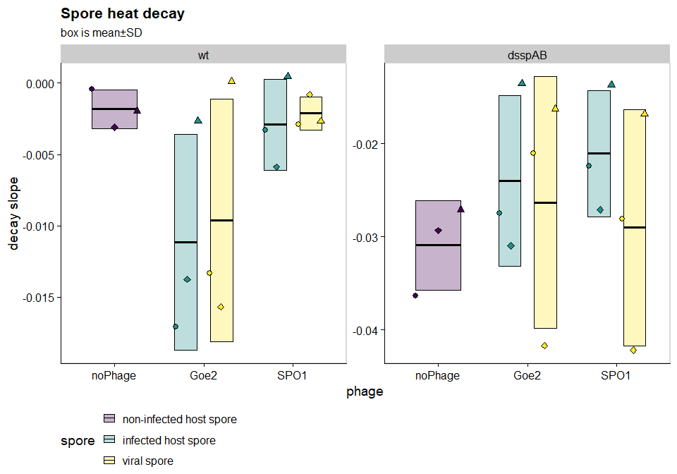

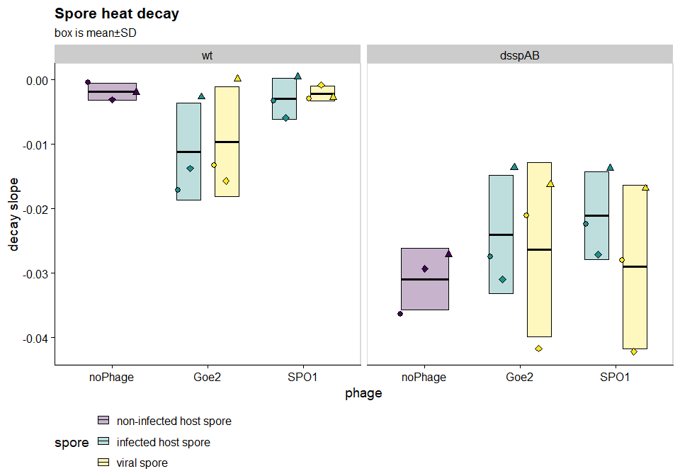

[output not shown]

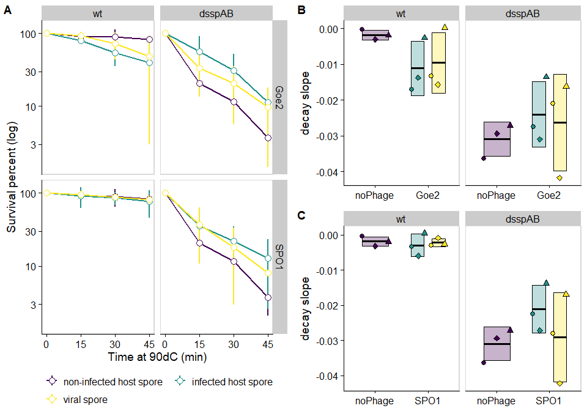

```r
#plot for outline
p.goe2 <- d.slopes%>%
  filter(phage!="SPO1")%>%
  ggplot(aes(x=phage, y=estimate))+
  geom_crossbar(data=filter(sum.slopes,phage!="SPO1"), aes(ymin=ymin, ymax=ymax, fill=spore),alpha=.3, position = position_dodge(width=.8), width=.5)+
  geom_point(aes(fill=spore, shape=group),size=2, stroke=1,position = position_jitterdodge(jitter.width = 0.01,jitter.height = 0),show.legend = F)+
  scale_shape_manual(values = c(21,23,24))+
    theme_cowplot()+
  panel_border()+
  scale_fill_viridis_d()+
  ylab("decay slope")+
    theme(legend.position = "none",
          axis.title.x = element_blank())+
          # axis.text.x = element_text(angle = 30, hjust = 1))+
  facet_wrap(~host,nrow = 1)

p.spo1 <- d.slopes%>%
  filter(phage!="Goe2")%>%
  ggplot(aes(x=phage, y=estimate))+
  geom_crossbar(data=filter(sum.slopes,phage!="Goe2"), aes(ymin=ymin, ymax=ymax, fill=spore),alpha=.3, position = position_dodge(width=.8), width=.5)+
  geom_point(aes(fill=spore, shape=group),size=2, stroke=1,position = position_jitterdodge(jitter.width = 0.01,jitter.height = 0),show.legend = F)+
  scale_shape_manual(values = c(21,23,24))+
  theme_cowplot()+
  panel_border()+
  scale_fill_viridis_d()+
  ylab("decay slope")+
    theme(legend.position = "none",
          axis.title.x = element_blank())+
  facet_wrap(~host,nrow = 1)

right.col <- plot_grid(p.goe2,p.spo1, ncol = 1, labels = LETTERS[2:3])

plot_grid(p.decay,right.col,
          labels = c("A",""))+
  ggsave2(here("figures", "lines_and_slopes.png"),
          width = 8,height = 5)
```